# Bike-Sharing Case Study

Sevan Agopyan

2023-04-29

[figure not shown]

Bike Sharing System

## Study Overview

- **Ask**
- **Prepare**
- **Process**
- **Analyze**
- **Share**
- **Act**

## Ask Phase

Asking the relevant and open ended questions while considering the needs of stakeholder is the key parts of **Ask** phase.

- **Identify the business task:** The task is to figure of how different customer types differ in using the service?
- **How can these insights drive business decisions?:** Based on the observations marketing campaign will be shaped.

## Prepare

Below are questions that need to be answered in **Prepare** phase

- Where is your data located?: Data located in the cloud.
- How is the data organized?: Data is organized as csv files for each month for the past 12 months.
- Are there issues with bias or credibility in this data? Does your data ROCCC?
- How are you addressing licensing, privacy, security, and accessibility?: Data that is provided is a open source public data meaning the data can be used, manipulated and shared freely.
- How did you verify the data’s integrity? Data integrity means that it is clean, complete, consistent, and relevant.
- How does it help you answer your question? The granularity and the context of the data allow us to achieve the business task
- Are there any problems with the data?: There are some missing station names within data. I am not expecting to have problem, because I will not include station names in analysis.  
  In the Prepare stage I downloaded monthly csv data separately. Checked their integrity using spreadsheet program. I also confirmed that there is no accessibility issues and the data covers the expectations of the business task.

## Process

Is the phase where the data is processed and gets ready for analysis.  
Below are the questions that needs to be answered during the process stage:

- What tools will be used: I decided to use R. R is great for data data wrangling and manipulation including statistics. It also has a great tool for data visualization called **ggplot2**
- What steps have been taken for data cleaning: R code blocks presented below ensures clean data.
- Have you documented your cleaning process so you can review and share those results?: One of the reasons I choose R over spreadsheet application is reproducability.

Below are the steps followed for the process stage.

1. Download the previous 12 months of **Byky** trip data.
2. Unzip the files.
3. Create a dedicated folder on my desktop to house the files. Used appropriate file-naming conventions.
4. Create subfolders for the .CSV files. downloaded files to the appropriate subfolder.
5. Launch Excel, open each file, and choose to Save As an Excel Workbook file. Put it in the subfolder you created for .XLS files.
6. Open your spreadsheet and create a column called “ride_length.” Calculate the length of each ride by subtracting the column “started_at” from the column “ended_at” (for example, =D2-C2) and format as HH:MM:SS using Format > Cells > Time > 37:30:55.
7. Create a column called “day_of_week,” and calculate the day of the week that each ride started using the “WEEKDAY” command (for example, =WEEKDAY(C2,1)) in each file. Format as General or as a number with no decimals, noting that 1 = Sunday and 7 = Saturday.

## Analyze

Now that data is stored appropriately and has been prepared for analysis, start putting it to work.  
Below are the tasks that were performed during Analyze phase.

1. Aggregate your data so it’s useful and accessible.
2. Organize and format your data.
3. Perform calculations.
4. Identify trends and relationships.

The purpose of this script is to consolidate downloaded Byky data into a single dataframe and then conduct simple analysis to help answer the key question: **In what ways do members and casual riders use bikes differently?**  
We will start by installing and loading the appropriate packages to conduct this analysis:

- `tidyverse` for data import and manipulation. This library also includes `ggplot2` for data visualization
- `lubridate` for date functions

Below code loads the installed packages

```r
library(tidyverse)
library(lubridate)
```

It is time to get and set the current working directory to prevent any potential issues may arise when connecting to data files

```r
getwd()
```

```
## [1] "C:/Users/sevan/Desktop/Case_Study_Byky"
```

We have to load files into tibbles. For the purpose we are going to use `read_csv` function that is part of `readr` package, that is part of core `tidyverse` library. If you’ve used R before, you might wonder why I am not using read.csv(). There are a few good reasons to favour readr functions over the base equivalents:

- `readr` functions are much more faster (~10x times)
- They produce tibbles, they don’t convert character vectors to factors, use row names, or munge the column names. These are common sources of frustration with the base R functions.
- They are more reproducible. Base R functions inherit some behavior from your operating system and environment variables, so import code that works on your computer might not work on someone else’s.

While the names don’t have to be in the same order, they DO need to match perfectly before we can use a command to join them into one file. Below `glimpse` function is handy for this specific case, since it displays the column names and their data type side to side.

```r
glimpse(d202204)
```

```
## Rows: 371,249
## Columns: 13
## $ ride_id            <chr> "3564070EEFD12711", "0B820C7FCF22F489", "89EEEE3229…
## $ rideable_type      <chr> "electric_bike", "classic_bike", "classic_bike", "c…
## $ started_at         <dttm> 2022-04-06 17:42:48, 2022-04-24 19:23:07, 2022-04-…
## $ ended_at           <dttm> 2022-04-06 17:54:36, 2022-04-24 19:43:17, 2022-04-…
## $ start_station_name <chr> "Paulina St & Howard St", "Wentworth Ave & Cermak R…
## $ start_station_id   <chr> "515", "13075", "TA1307000121", "13075", "TA1307000…
## $ end_station_name   <chr> "University Library (NU)", "Green St & Madison St",…
## $ end_station_id     <chr> "605", "TA1307000120", "TA1307000120", "KA170600500…
## $ start_lat          <dbl> 42.01913, 41.85308, 41.87184, 41.85308, 41.87181, 4…
## $ start_lng          <dbl> -87.67353, -87.63193, -87.64664, -87.63193, -87.646…
## $ end_lat            <dbl> 42.05294, 41.88189, 41.88189, 41.86749, 41.88224, 4…
## $ end_lng            <dbl> -87.67345, -87.64879, -87.64879, -87.63219, -87.641…
## $ member_casual      <chr> "member", "member", "member", "casual", "member", "…
```

```r
glimpse(d202205)
```

```
## Rows: 634,858
## Columns: 13
## $ ride_id            <chr> "EC2DE40644C6B0F4", "1C31AD03897EE385", "1542FBEC83…
## $ rideable_type      <chr> "classic_bike", "classic_bike", "classic_bike", "cl…
## $ started_at         <dttm> 2022-05-23 23:06:58, 2022-05-11 08:53:28, 2022-05-…
## $ ended_at           <dttm> 2022-05-23 23:40:19, 2022-05-11 09:31:22, 2022-05-…
## $ start_station_name <chr> "Wabash Ave & Grand Ave", "DuSable Lake Shore Dr & …
## $ start_station_id   <chr> "TA1307000117", "13300", "TA1305000032", "TA1305000…
## $ end_station_name   <chr> "Halsted St & Roscoe St", "Field Blvd & South Water…
## $ end_station_id     <chr> "TA1309000025", "15534", "13221", "TA1305000030", "…
## $ start_lat          <dbl> 41.89147, 41.88096, 41.88224, 41.88224, 41.88224, 4…
## $ start_lng          <dbl> -87.62676, -87.61674, -87.64107, -87.64107, -87.641…
## $ end_lat            <dbl> 41.94367, 41.88635, 41.90765, 41.88458, 41.88578, 4…
## $ end_lng            <dbl> -87.64895, -87.61752, -87.67255, -87.63189, -87.651…
## $ member_casual      <chr> "member", "member", "member", "member", "member", "…
```

```r
glimpse(d202206)
```

```
## Rows: 769,204
## Columns: 13
## $ ride_id            <chr> "600CFD130D0FD2A4", "F5E6B5C1682C6464", "B6EB6D27BA…
## $ rideable_type      <chr> "electric_bike", "electric_bike", "electric_bike", …
## $ started_at         <dttm> 2022-06-30 17:27:53, 2022-06-30 18:39:52, 2022-06-…
## $ ended_at           <dttm> 2022-06-30 17:35:15, 2022-06-30 18:47:28, 2022-06-…
## $ start_station_name <chr> NA, NA, NA, NA, NA, NA, NA, NA, NA, NA, NA, NA, NA,…
## $ start_station_id   <chr> NA, NA, NA, NA, NA, NA, NA, NA, NA, NA, NA, NA, NA,…
## $ end_station_name   <chr> NA, NA, NA, NA, NA, NA, NA, NA, NA, NA, NA, NA, NA,…
## $ end_station_id     <chr> NA, NA, NA, NA, NA, NA, NA, NA, NA, NA, NA, NA, NA,…
## $ start_lat          <dbl> 41.89, 41.91, 41.91, 41.80, 41.91, 42.03, 41.91, 41…
## $ start_lng          <dbl> -87.62, -87.62, -87.65, -87.66, -87.63, -87.71, -87…
## $ end_lat            <dbl> 41.91, 41.93, 41.89, 41.80, 41.93, 42.06, 41.92, 41…
## $ end_lng            <dbl> -87.62, -87.63, -87.61, -87.65, -87.64, -87.73, -87…
## $ member_casual      <chr> "casual", "casual", "casual", "casual", "casual", "…
```

```r
glimpse(d202207)
```

```
## Rows: 823,488
## Columns: 13
## $ ride_id            <chr> "954144C2F67B1932", "292E027607D218B6", "5776585258…
## $ rideable_type      <chr> "classic_bike", "classic_bike", "classic_bike", "cl…
## $ started_at         <dttm> 2022-07-05 08:12:47, 2022-07-26 12:53:38, 2022-07-…
## $ ended_at           <dttm> 2022-07-05 08:24:32, 2022-07-26 12:55:31, 2022-07-…
## $ start_station_name <chr> "Ashland Ave & Blackhawk St", "Buckingham Fountain …
## $ start_station_id   <chr> "13224", "15541", "15541", "15541", "TA1307000117",…
## $ end_station_name   <chr> "Kingsbury St & Kinzie St", "Michigan Ave & 8th St"…
## $ end_station_id     <chr> "KA1503000043", "623", "623", "TA1307000164", "TA13…
## $ start_lat          <dbl> 41.90707, 41.86962, 41.86962, 41.86962, 41.89147, 4…
## $ start_lng          <dbl> -87.66725, -87.62398, -87.62398, -87.62398, -87.626…
## $ end_lat            <dbl> 41.88918, 41.87277, 41.87277, 41.79526, 41.93625, 4…
## $ end_lng            <dbl> -87.63851, -87.62398, -87.62398, -87.59647, -87.652…
## $ member_casual      <chr> "member", "casual", "casual", "casual", "member", "…
```

```r
glimpse(d202208)
```

```
## Rows: 785,932
## Columns: 13
## $ ride_id            <chr> "550CF7EFEAE0C618", "DAD198F405F9C5F5", "E6F2BC47B6…
## $ rideable_type      <chr> "electric_bike", "electric_bike", "electric_bike", …
## $ started_at         <dttm> 2022-08-07 21:34:15, 2022-08-08 14:39:21, 2022-08-…
## $ ended_at           <dttm> 2022-08-07 21:41:46, 2022-08-08 14:53:23, 2022-08-…
## $ start_station_name <chr> NA, NA, NA, NA, NA, NA, NA, NA, NA, NA, NA, NA, NA,…
## $ start_station_id   <chr> NA, NA, NA, NA, NA, NA, NA, NA, NA, NA, NA, NA, NA,…
## $ end_station_name   <chr> NA, NA, NA, NA, NA, NA, NA, NA, NA, NA, NA, NA, NA,…
## $ end_station_id     <chr> NA, NA, NA, NA, NA, NA, NA, NA, NA, NA, NA, NA, NA,…
## $ start_lat          <dbl> 41.93, 41.89, 41.97, 41.94, 41.85, 41.79, 41.89, 41…
## $ start_lng          <dbl> -87.69, -87.64, -87.69, -87.65, -87.65, -87.72, -87…
## $ end_lat            <dbl> 41.94, 41.92, 41.97, 41.97, 41.84, 41.82, 41.89, 41…
## $ end_lng            <dbl> -87.72, -87.64, -87.66, -87.69, -87.66, -87.69, -87…
## $ member_casual      <chr> "casual", "casual", "casual", "casual", "casual", "…
```

```r
glimpse(d202209)
```

```
## Rows: 701,339
## Columns: 13
## $ ride_id            <chr> "5156990AC19CA285", "E12D4A16BF51C274", "A02B53CD7D…
## $ rideable_type      <chr> "electric_bike", "electric_bike", "electric_bike", …
## $ started_at         <dttm> 2022-09-01 08:36:22, 2022-09-01 17:11:29, 2022-09-…
## $ ended_at           <dttm> 2022-09-01 08:39:05, 2022-09-01 17:14:45, 2022-09-…
## $ start_station_name <chr> NA, NA, NA, NA, NA, NA, NA, NA, NA, NA, NA, NA, NA,…
## $ start_station_id   <chr> NA, NA, NA, NA, NA, NA, NA, NA, NA, NA, NA, NA, NA,…
## $ end_station_name   <chr> "California Ave & Milwaukee Ave", NA, NA, NA, NA, N…
## $ end_station_id     <chr> "13084", NA, NA, NA, NA, NA, NA, NA, NA, NA, NA, NA…
## $ start_lat          <dbl> 41.93000, 41.87000, 41.87000, 41.93000, 41.92000, 4…
## $ start_lng          <dbl> -87.69000, -87.62000, -87.62000, -87.69000, -87.730…
## $ end_lat            <dbl> 41.92269, 41.87000, 41.87000, 41.94000, 41.92000, 4…
## $ end_lng            <dbl> -87.69715, -87.62000, -87.62000, -87.67000, -87.730…
## $ member_casual      <chr> "casual", "casual", "casual", "casual", "casual", "…
```

```r
glimpse(d202210)
```

```
## Rows: 558,685
## Columns: 13
## $ ride_id            <chr> "A50255C1E17942AB", "DB692A70BD2DD4E3", "3C02727AAF…
## $ rideable_type      <chr> "classic_bike", "electric_bike", "electric_bike", "…
## $ started_at         <dttm> 2022-10-14 17:13:30, 2022-10-01 16:29:26, 2022-10-…
## $ ended_at           <dttm> 2022-10-14 17:19:39, 2022-10-01 16:49:06, 2022-10-…
## $ start_station_name <chr> "Noble St & Milwaukee Ave", "Damen Ave & Charleston…
## $ start_station_id   <chr> "13290", "13288", "655", "KA1504000133", "13028", "…
## $ end_station_name   <chr> "Larrabee St & Division St", "Damen Ave & Cullerton…
## $ end_station_id     <chr> "KA1504000079", "13089", "TA1307000140", "620", "13…
## $ start_lat          <dbl> 41.90068, 41.92004, 41.97988, 41.90227, 41.87475, 4…
## $ start_lng          <dbl> -87.66260, -87.67794, -87.68190, -87.62769, -87.649…
## $ end_lat            <dbl> 41.90349, 41.85497, 41.96640, 41.89820, 41.86610, 4…
## $ end_lng            <dbl> -87.64335, -87.67570, -87.68870, -87.63754, -87.607…
## $ member_casual      <chr> "member", "casual", "member", "member", "casual", "…
```

```r
glimpse(d202211)
```

```
## Rows: 337,735
## Columns: 13
## $ ride_id            <chr> "BCC66FC6FAB27CC7", "772AB67E902C180F", "585EAD07FD…
## $ rideable_type      <chr> "electric_bike", "classic_bike", "classic_bike", "c…
## $ started_at         <dttm> 2022-11-10 06:21:55, 2022-11-04 07:31:55, 2022-11-…
## $ ended_at           <dttm> 2022-11-10 06:31:27, 2022-11-04 07:46:25, 2022-11-…
## $ start_station_name <chr> "Canal St & Adams St", "Canal St & Adams St", "Indi…
## $ start_station_id   <chr> "13011", "13011", "SL-005", "SL-005", "SL-005", "13…
## $ end_station_name   <chr> "St. Clair St & Erie St", "St. Clair St & Erie St",…
## $ end_station_id     <chr> "13016", "13016", "13016", "13016", "13016", "TA130…
## $ start_lat          <dbl> 41.87940, 41.87926, 41.86789, 41.86789, 41.86789, 4…
## $ start_lng          <dbl> -87.63985, -87.63990, -87.62304, -87.62304, -87.623…
## $ end_lat            <dbl> 41.89435, 41.89435, 41.89435, 41.89435, 41.89435, 4…
## $ end_lng            <dbl> -87.62280, -87.62280, -87.62280, -87.62280, -87.622…
## $ member_casual      <chr> "member", "member", "member", "member", "member", "…
```

```r
glimpse(d202212)
```

```
## Rows: 181,806
## Columns: 13
## $ ride_id            <chr> "65DBD2F447EC51C2", "0C201AA7EA0EA1AD", "E0B148CCB3…
## $ rideable_type      <chr> "electric_bike", "classic_bike", "electric_bike", "…
## $ started_at         <dttm> 2022-12-05 10:47:18, 2022-12-18 06:42:33, 2022-12-…
## $ ended_at           <dttm> 2022-12-05 10:56:34, 2022-12-18 07:08:44, 2022-12-…
## $ start_station_name <chr> "Clifton Ave & Armitage Ave", "Broadway & Belmont A…
## $ start_station_id   <chr> "TA1307000163", "13277", "TA1306000015", "KA1503000…
## $ end_station_name   <chr> "Sedgwick St & Webster Ave", "Sedgwick St & Webster…
## $ end_station_id     <chr> "13191", "13191", "13016", "13134", "13288", "KA150…
## $ start_lat          <dbl> 41.91824, 41.94011, 41.88592, 41.83846, 41.89595, 4…
## $ start_lng          <dbl> -87.65711, -87.64545, -87.65113, -87.63541, -87.667…
## $ end_lat            <dbl> 41.92217, 41.92217, 41.89435, 41.88137, 41.92008, 4…
## $ end_lng            <dbl> -87.63889, -87.63889, -87.62280, -87.67493, -87.677…
## $ member_casual      <chr> "member", "casual", "member", "member", "casual", "…
```

```r
glimpse(d202301)
```

```
## Rows: 190,301
## Columns: 13
## $ ride_id            <chr> "F96D5A74A3E41399", "13CB7EB698CEDB88", "BD88A2E670…
## $ rideable_type      <chr> "electric_bike", "classic_bike", "electric_bike", "…
## $ started_at         <dttm> 2023-01-21 20:05:42, 2023-01-10 15:37:36, 2023-01-…
## $ ended_at           <dttm> 2023-01-21 20:16:33, 2023-01-10 15:46:05, 2023-01-…
## $ start_station_name <chr> "Lincoln Ave & Fullerton Ave", "Kimbark Ave & 53rd …
## $ start_station_id   <chr> "TA1309000058", "TA1309000037", "RP-005", "TA130900…
## $ end_station_name   <chr> "Hampden Ct & Diversey Ave", "Greenwood Ave & 47th …
## $ end_station_id     <chr> "202480.0", "TA1308000002", "599", "TA1308000002", …
## $ start_lat          <dbl> 41.92407, 41.79957, 42.00857, 41.79957, 41.79957, 4…
## $ start_lng          <dbl> -87.64628, -87.59475, -87.69048, -87.59475, -87.594…
## $ end_lat            <dbl> 41.93000, 41.80983, 42.03974, 41.80983, 41.80983, 4…
## $ end_lng            <dbl> -87.64000, -87.59938, -87.69941, -87.59938, -87.599…
## $ member_casual      <chr> "member", "member", "casual", "member", "member", "…
```

```r
glimpse(d202302)
```

```
## Rows: 190,445
## Columns: 13
## $ ride_id            <chr> "CBCD0D7777F0E45F", "F3EC5FCE5FF39DE9", "E54C1F27FA…
## $ rideable_type      <chr> "classic_bike", "electric_bike", "classic_bike", "e…
## $ started_at         <dttm> 2023-02-14 11:59:42, 2023-02-15 13:53:48, 2023-02-…
## $ ended_at           <dttm> 2023-02-14 12:13:38, 2023-02-15 13:59:08, 2023-02-…
## $ start_station_name <chr> "Southport Ave & Clybourn Ave", "Clarendon Ave & Go…
## $ start_station_id   <chr> "TA1309000030", "13379", "TA1309000030", "TA1309000…
## $ end_station_name   <chr> "Clark St & Schiller St", "Sheridan Rd & Lawrence A…
## $ end_station_id     <chr> "TA1309000024", "TA1309000041", "13156", "TA1309000…
## $ start_lat          <dbl> 41.92077, 41.95788, 41.92077, 41.92087, 41.79483, 4…
## $ start_lng          <dbl> -87.66371, -87.64958, -87.66371, -87.66373, -87.618…
## $ end_lat            <dbl> 41.90799, 41.96952, 41.88042, 41.87943, 41.78053, 4…
## $ end_lng            <dbl> -87.63150, -87.65469, -87.65552, -87.63550, -87.605…
## $ member_casual      <chr> "casual", "casual", "member", "member", "member", "…
```

```r
glimpse(d202303)
```

```
## Rows: 258,678
## Columns: 13
## $ ride_id            <chr> "6842AA605EE9FBB3", "F984267A75B99A8C", "FF7CF57CFE…
## $ rideable_type      <chr> "electric_bike", "electric_bike", "classic_bike", "…
## $ started_at         <dttm> 2023-03-16 08:20:34, 2023-03-04 14:07:06, 2023-03-…
## $ ended_at           <dttm> 2023-03-16 08:22:52, 2023-03-04 14:15:31, 2023-03-…
## $ start_station_name <chr> "Clark St & Armitage Ave", "Public Rack - Kedzie Av…
## $ start_station_id   <chr> "13146", "491", "620", "TA1306000003", "18067", "62…
## $ end_station_name   <chr> "Larrabee St & Webster Ave", NA, "Clark St & Randol…
## $ end_station_id     <chr> "13193", NA, "TA1305000030", "13154", "TA1306000015…
## $ start_lat          <dbl> 41.91841, 41.97000, 41.89820, 41.88872, 41.91448, 4…
## $ start_lng          <dbl> -87.63645, -87.71000, -87.63754, -87.64445, -87.668…
## $ end_lat            <dbl> 41.92182, 41.95000, 41.88458, 41.91052, 41.88578, 4…
## $ end_lng            <dbl> -87.64414, -87.71000, -87.63189, -87.65311, -87.651…
## $ member_casual      <chr> "member", "member", "member", "member", "member", "…
```

after ensuring that column names and data structures match and consistent, now can append all tables into a single table containing a full-year data.

```r
full_year <- bind_rows(d202204, d202205, d202206, d202207, d202208, d202209, d202210,
          d202211, d202212, d202301, d202302, d202303)
```

we need to select only the relevent colums. For this, we use `select()` function provided by `dplyr` package. We will skip the columsn *start_station_id*, *end_station_id*

```r
full_year <- full_year %>%
  select(-c(start_station_id, end_station_id))
head(full_year)
```

```
## # A tibble: 6 × 11
##   ride_id          rideable_type started_at          ended_at
##   <chr>            <chr>         <dttm>              <dttm>
## 1 3564070EEFD12711 electric_bike 2022-04-06 17:42:48 2022-04-06 17:54:36
## 2 0B820C7FCF22F489 classic_bike  2022-04-24 19:23:07 2022-04-24 19:43:17
## 3 89EEEE32293F07FF classic_bike  2022-04-20 19:29:08 2022-04-20 19:35:16
## 4 84D4751AEB31888D classic_bike  2022-04-22 21:14:06 2022-04-22 21:23:29
## 5 5664BCF0D1DE7A8B electric_bike 2022-04-16 15:56:30 2022-04-16 16:02:11
## 6 AA9EB7BD2E1FC128 classic_bike  2022-04-21 16:52:33 2022-04-21 16:56:51
## # ℹ 7 more variables: start_station_name <chr>, end_station_name <chr>,
## #   start_lat <dbl>, start_lng <dbl>, end_lat <dbl>, end_lng <dbl>,
## #   member_casual <chr>
```

### CLEAN UP AND ADD DATA TO PREPARE FOR ANALYSIS

It is time to inspect the table that has been created

```r
colnames(full_year)  #List of column names
```

```
##  [1] "ride_id"            "rideable_type"      "started_at"
##  [4] "ended_at"           "start_station_name" "end_station_name"
##  [7] "start_lat"          "start_lng"          "end_lat"
## [10] "end_lng"            "member_casual"
```

```r
nrow(full_year)  #How many rows are in data frame?
```

```
## [1] 5803720
```

```r
dim(full_year)  #Dimensions of the data frame?
```

```
## [1] 5803720      11
```

```r
head(full_year)  #See the first 6 rows of data frame.  Also tail(all_trips)
```

```
## # A tibble: 6 × 11
##   ride_id          rideable_type started_at          ended_at
##   <chr>            <chr>         <dttm>              <dttm>
## 1 3564070EEFD12711 electric_bike 2022-04-06 17:42:48 2022-04-06 17:54:36
## 2 0B820C7FCF22F489 classic_bike  2022-04-24 19:23:07 2022-04-24 19:43:17
## 3 89EEEE32293F07FF classic_bike  2022-04-20 19:29:08 2022-04-20 19:35:16
## 4 84D4751AEB31888D classic_bike  2022-04-22 21:14:06 2022-04-22 21:23:29
## 5 5664BCF0D1DE7A8B electric_bike 2022-04-16 15:56:30 2022-04-16 16:02:11
## 6 AA9EB7BD2E1FC128 classic_bike  2022-04-21 16:52:33 2022-04-21 16:56:51
## # ℹ 7 more variables: start_station_name <chr>, end_station_name <chr>,
## #   start_lat <dbl>, start_lng <dbl>, end_lat <dbl>, end_lng <dbl>,
## #   member_casual <chr>
```

```r
str(full_year)  #See list of columns and data types (numeric, character, etc)
```

```
## tibble [5,803,720 × 11] (S3: tbl_df/tbl/data.frame)
##  $ ride_id           : chr [1:5803720] "3564070EEFD12711" "0B820C7FCF22F489" "89EEEE32293F07FF" "84D4751AEB31888D" ...
##  $ rideable_type     : chr [1:5803720] "electric_bike" "classic_bike" "classic_bike" "classic_bike" ...
##  $ started_at        : POSIXct[1:5803720], format: "2022-04-06 17:42:48" "2022-04-24 19:23:07" ...
##  $ ended_at          : POSIXct[1:5803720], format: "2022-04-06 17:54:36" "2022-04-24 19:43:17" ...
##  $ start_station_name: chr [1:5803720] "Paulina St & Howard St" "Wentworth Ave & Cermak Rd" "Halsted St & Polk St" "Wentworth Ave & Cermak Rd" ...
##  $ end_station_name  : chr [1:5803720] "University Library (NU)" "Green St & Madison St" "Green St & Madison St" "Delano Ct & Roosevelt Rd" ...
##  $ start_lat         : num [1:5803720] 42 41.9 41.9 41.9 41.9 ...
##  $ start_lng         : num [1:5803720] -87.7 -87.6 -87.6 -87.6 -87.6 ...
##  $ end_lat           : num [1:5803720] 42.1 41.9 41.9 41.9 41.9 ...
##  $ end_lng           : num [1:5803720] -87.7 -87.6 -87.6 -87.6 -87.6 ...
##  $ member_casual     : chr [1:5803720] "member" "member" "member" "casual" ...
```

```r
summary(full_year)  #Statistical summary of data. Mainly for numerics
```

```
##    ride_id          rideable_type        started_at
##  Length:5803720     Length:5803720     Min.   :2022-04-01 00:01:48.00
##  Class :character   Class :character   1st Qu.:2022-06-18 23:27:00.25
##  Mode  :character   Mode  :character   Median :2022-08-13 11:37:32.00
##                                        Mean   :2022-08-25 07:04:55.95
##                                        3rd Qu.:2022-10-14 18:04:21.00
##                                        Max.   :2023-03-31 23:59:28.00
##
##     ended_at                      start_station_name end_station_name
##  Min.   :2022-04-01 00:02:15.00   Length:5803720     Length:5803720
##  1st Qu.:2022-06-18 23:51:55.75   Class :character   Class :character
##  Median :2022-08-13 12:00:07.50   Mode  :character   Mode  :character
##  Mean   :2022-08-25 07:23:54.70
##  3rd Qu.:2022-10-14 18:19:10.25
##  Max.   :2023-04-03 11:41:11.00
##
##    start_lat       start_lng         end_lat         end_lng
##  Min.   :41.64   Min.   :-87.84   Min.   : 0.00   Min.   :-88.14
##  1st Qu.:41.88   1st Qu.:-87.66   1st Qu.:41.88   1st Qu.:-87.66
##  Median :41.90   Median :-87.64   Median :41.90   Median :-87.64
##  Mean   :41.90   Mean   :-87.65   Mean   :41.90   Mean   :-87.65
##  3rd Qu.:41.93   3rd Qu.:-87.63   3rd Qu.:41.93   3rd Qu.:-87.63
##  Max.   :42.07   Max.   :-87.52   Max.   :42.37   Max.   :  0.00
##                                   NA's   :5855    NA's   :5855
##  member_casual
##  Length:5803720
##  Class :character
##  Mode  :character
##
##
##
##
```

We need to view the distinct values inside **member_casual** column to be sure if the values meet our expectations.

```r
full_year %>%
  distinct(member_casual)
```

```
## # A tibble: 2 × 1
##   member_casual
##   <chr>
## 1 member
## 2 casual
```

we are now sure the column **member_casual** has two separate values there are *member* and *casual*  
checking the number of distinct values for*start_station_name* and *end_station_name* will also beneficial

```r
n_distinct(full_year$start_station_name)
```

```
## [1] 1700
```

```r
n_distinct(full_year$end_station_name)
```

```
## [1] 1724
```

We see that there are **1700** start stations and **1724** end stations

The data can only be aggregated at the **ride_id** level, which is too granular. We will want to add some additional columns of data, such as day, month, year – that provide additional opportunities to aggregate the data.

```r
full_year_modified <- full_year %>%
  mutate(year=year(started_at), month = month(started_at),
         day_of_month = mday(started_at), day_of_week = wday(started_at),
         trip_length = as.numeric(ended_at - started_at))

select(full_year_modified, ended_at, started_at, trip_length, year, month, day_of_week) %>%
  arrange(trip_length)
```

```
## # A tibble: 5,803,720 × 6
##    ended_at            started_at          trip_length  year month day_of_week
##    <dttm>              <dttm>                    <dbl> <dbl> <dbl>       <dbl>
##  1 2022-09-21 06:31:11 2022-09-28 11:04:32     -621201  2022     9           4
##  2 2022-10-13 11:53:28 2022-10-13 14:42:10      -10122  2022    10           5
##  3 2022-06-07 17:05:38 2022-06-07 19:23:03       -8245  2022     6           3
##  4 2022-06-07 17:05:37 2022-06-07 19:15:39       -7802  2022     6           3
##  5 2022-06-07 17:05:42 2022-06-07 19:14:47       -7745  2022     6           3
##  6 2022-06-07 17:07:45 2022-06-07 19:14:46       -7621  2022     6           3
##  7 2022-06-07 17:05:24 2022-06-07 19:11:33       -7569  2022     6           3
##  8 2022-06-07 17:07:57 2022-06-07 19:13:27       -7530  2022     6           3
##  9 2022-06-07 17:09:43 2022-06-07 19:06:49       -7026  2022     6           3
## 10 2022-06-07 17:05:41 2022-06-07 18:47:01       -6080  2022     6           3
## # ℹ 5,803,710 more rows
```

sorting the above data by trip_length in ascending order reveal the rows with negative values that are not relevant. Negative values indicate the bikes were taken for repair and/check purpose by the company. We have to create a new version pf our dataframe where negative values are omitted.

```r
full_year_modified_v2 <- full_year_modified[!(full_year_modified$trip_length<=0 | full_year_modified$start_station_name == "HQ QR"),]
```

```r
summary(full_year_modified_v2$trip_length)
```

```
##    Min. 1st Qu.  Median    Mean 3rd Qu.    Max.    NA's
##       1     349     615    1200    1105 2483235  839055
```

It seems there are NA values for trip length. We have to get rid of them

```r
full_year_modified_v2 <- full_year_modified_v2[!(is.na(full_year_modified_v2$trip_length)),]
summary(full_year_modified_v2$trip_length)
```

```
##    Min. 1st Qu.  Median    Mean 3rd Qu.    Max.
##       1     349     615    1200    1105 2483235
```

Descriptive Analysis on member type

```r
member_type_summary <- full_year_modified_v2 %>%
  group_by(member_casual) %>%
  summarise(mean_trip_duration_seconds = mean(trip_length),
            mean_trip_duration_minutes = mean(trip_length)/60,
            median_trip_duratin = median(trip_length),
            max_trip_duration_hours = max(trip_length)/60/60,
            min_trip_duration = min(trip_length),
            n = n())
head(member_type_summary)
```

```
## # A tibble: 2 × 7
##   member_casual mean_trip_duration_seconds mean_trip_duration_minutes
##   <chr>                              <dbl>                      <dbl>
## 1 casual                             1866.                       31.1
## 2 member                              755.                       12.6
## # ℹ 4 more variables: median_trip_duratin <dbl>, max_trip_duration_hours <dbl>,
## #   min_trip_duration <dbl>, n <int>
```

from the results these are obvious:

- customers with one-time pass or day_pass ride 2.4694202 times more than members in average
- on th other hand number of members 1.4944341 times more used the service

see the average trip time and count of trips for the week-days

```r
week_day_summary <- full_year_modified_v2 %>%
  group_by(day_of_week) %>%
  summarise(mean_trip_duration_seconds = mean(trip_length),
            mean_trip_duration_minutes = mean(trip_length)/60,
            median_trip_duratin = median(trip_length),
            max_trip_duration_hours = max(trip_length)/60/60,
            min_trip_duration = min(trip_length),
            n = n())
head(week_day_summary)
```

```
## # A tibble: 6 × 7
##   day_of_week mean_trip_duration_se…¹ mean_trip_duration_m…² median_trip_duratin
##         <dbl>                   <dbl>                  <dbl>               <dbl>
## 1           1                   1509.                   25.2                 723
## 2           2                   1133.                   18.9                 579
## 3           3                   1024.                   17.1                 560
## 4           4                    997.                   16.6                 562
## 5           5                   1047.                   17.4                 577
## 6           6                   1181.                   19.7                 603
## # ℹ abbreviated names: ¹mean_trip_duration_seconds, ²mean_trip_duration_minutes
## # ℹ 3 more variables: max_trip_duration_hours <dbl>, min_trip_duration <dbl>,
## #   n <int>
```

Now, let’s run the average ride time by each day for members vs casual users

```r
week_day_summary_per_customer_type <- full_year_modified_v2 %>%
  group_by(day_of_week, member_casual) %>%
  summarise(mean_trip_duration_seconds = mean(trip_length),
            mean_trip_duration_minutes = mean(trip_length)/60,
            median_trip_duratin = median(trip_length),
            max_trip_duration_hours = max(trip_length)/60/60,
            min_trip_duration = min(trip_length),
            n = n())
head(week_day_summary_per_customer_type)
```

```
## # A tibble: 6 × 8
## # Groups:   day_of_week [3]
##   day_of_week member_casual mean_trip_duration_seconds mean_trip_duration_minu…¹
##         <dbl> <chr>                              <dbl>                     <dbl>
## 1           1 casual                             2183.                      36.4
## 2           1 member                              841.                      14.0
## 3           2 casual                             1857.                      31.0
## 4           2 member                              726.                      12.1
## 5           3 casual                             1652.                      27.5
## 6           3 member                              718.                      12.0
## # ℹ abbreviated name: ¹mean_trip_duration_minutes
## # ℹ 4 more variables: median_trip_duratin <dbl>, max_trip_duration_hours <dbl>,
## #   min_trip_duration <dbl>, n <int>
```

## Share

This is the phase where insights driven by analysis are visualized, polished and shared with the stakeholders

the key tasks for this stage can be ordered as below;

1. Determine the best way to share your findings.
2. Create effective data visualizations.
3. Present your findings.
4. Ensure your work is accessible.

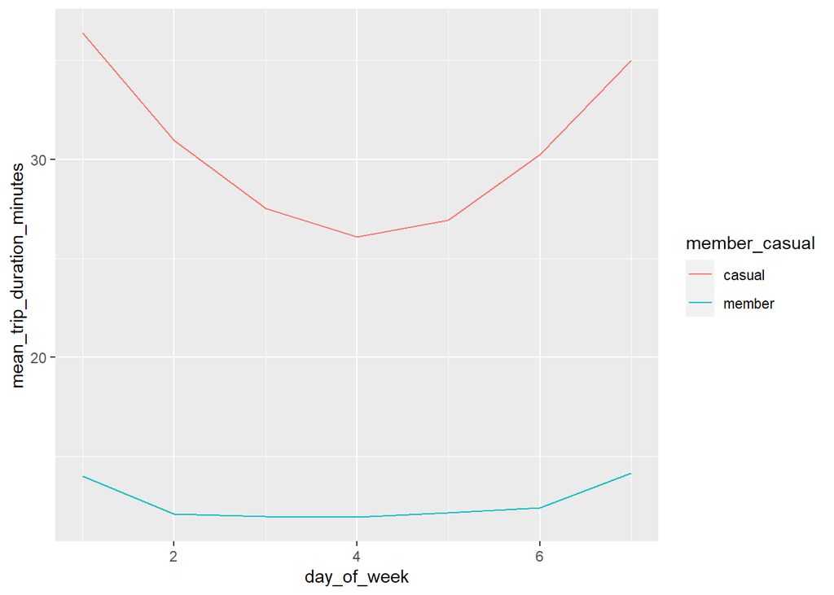

```r
week_day_summary_per_customer_type %>%
  ggplot(mapping = aes(x=day_of_week, y=mean_trip_duration_minutes, color = member_casual)) +
  geom_line()
```